# Bayesian model fitting

MCMC sampling

| Diogo Melo Lewis-Sigler Institute of Integrative Genomics damelo@princeton.edu |
| --- |

### Model fit

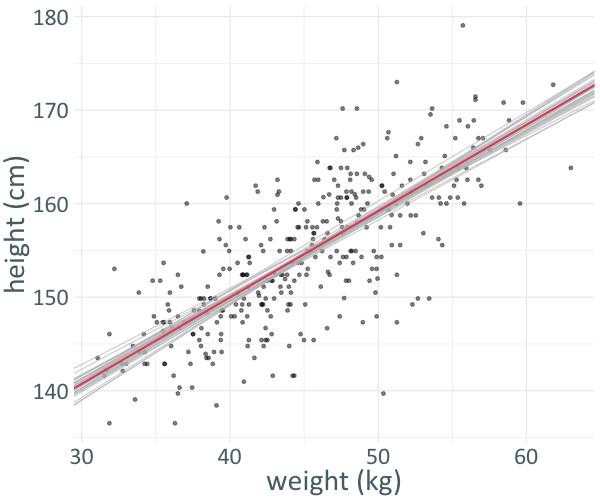

### Posterior samples

```python
> samples
# A tibble: 2,000 × 3
           a         b     sigma
   <dbl[1d]> <dbl[1d]> <dbl[1d]>
 1      115.     0.889      4.78
 2      109.     1.02       5.30
 3      112.     0.928      5.07
 4      111.     0.949      5.30
 5      111.     0.955      5.04
 6      115.     0.872      5.19
 7      109.     1.01       5.13
 8      117.     0.844      5.00
 9      115.     0.882      4.94
10      112.     0.939      4.95
# … with 1,990 more rows
```

## How to get posterior samples?

- There is no general method to find high probability regions in arbitrary probability distributions.
- This mean most models are fit using purely computational methods.

### curse of dimensionality

- For simple parameters spaces, we can do grid search or some brute force method to find high probability regions
- This breaks down quickly as the number of parameters increases

### high dimensional watermelons are awful

[figure not shown]

### typical set

[figure not shown]

### Multivariate gaussians

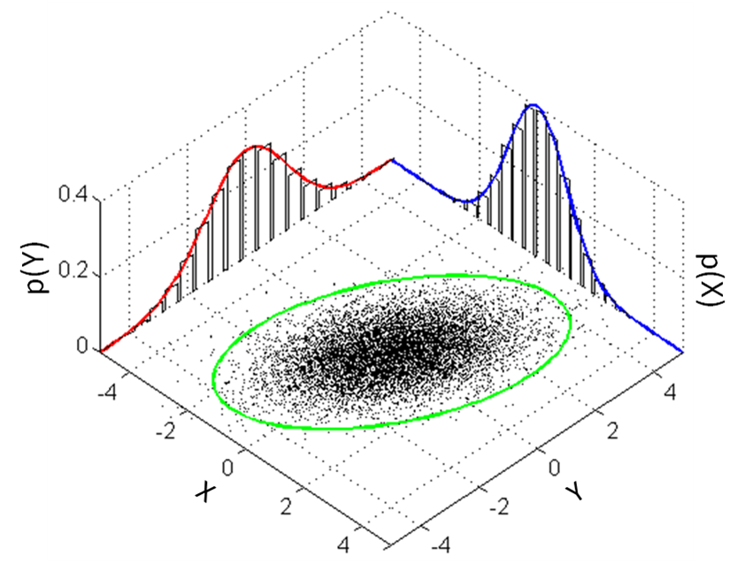

### Distance from mean in 2 dimensions

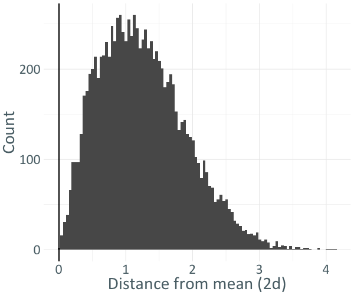

### Gaussian typical set

[figure not shown]

### finding high probability regions

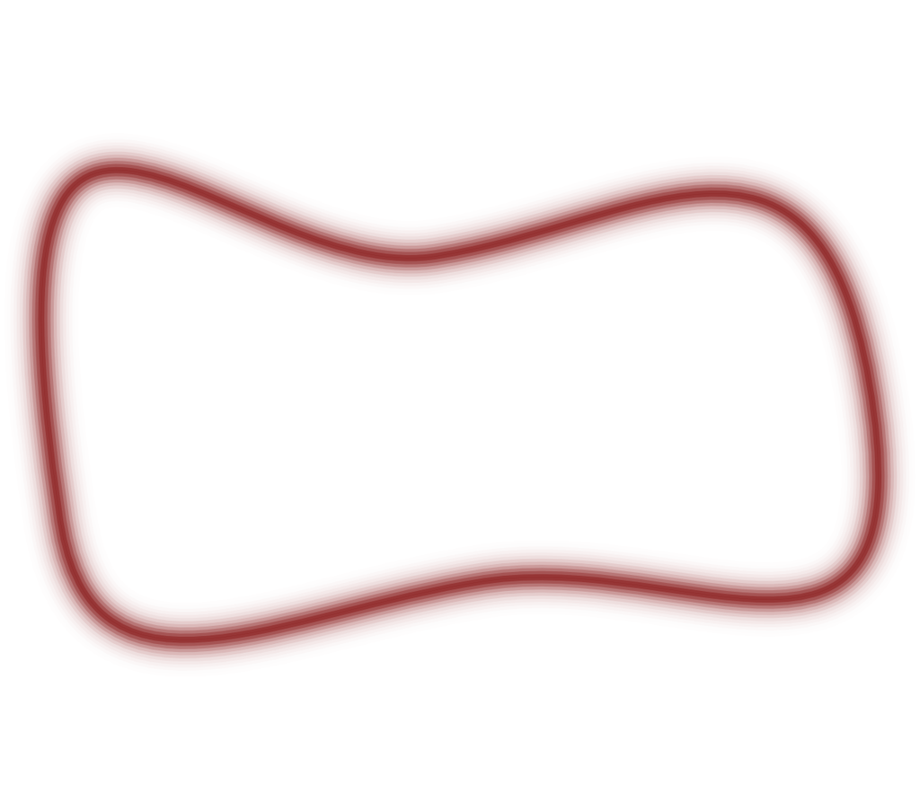

### mcmc method

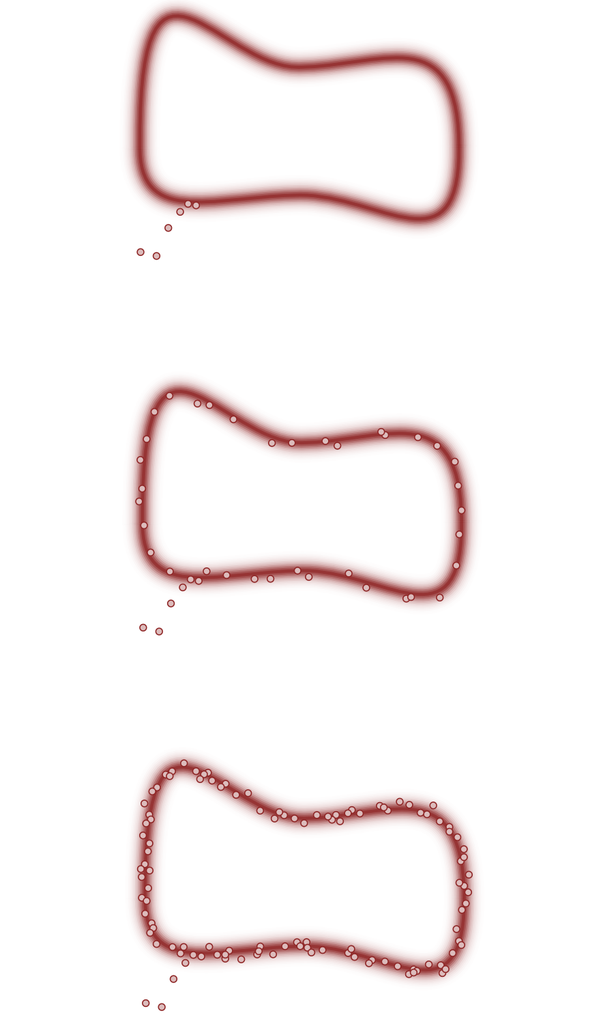

### MCMC samplers 2

- Gibbs samplers
  - Mostly surpassed, but still in wide use.
  - Can sample discrete parameters.
  - Requires particular types of priors.
  - Software: WinBugs, Bugs, Jags…
- Hamiltonian Monte Carlo samplers
  - Latest generations samplers.
  - Fast and general.
  - Discrete parameters must be integrated.
  - Can fit dynamic models using differential equations.
  - Software: PyMC3, Edward, Stan (rethinking engine)…

### what makes these samplers different?

Basically the transition proposal distribution

### Our model from yesterday

### Code in rethinking

Model

Code

```python
 # Data
library(rethinking)
d2 <- Howell1[ Howell1$age >= 18 , ]

# Model
ulam(alist(
  y ~ normal(mu, sigma),
  mu <- a + b * x,
  a ~ normal(0, 20),
  b ~ lognormal(0, 1),
  sigma ~ exponential(1)),
  data = list(y = d2$height,
              x = d2$weight),
  iter = 1000, chains = 4, cores = 4)
```

### rethinking generates stan code

```
data{
    vector[352] y;
    vector[352] x;
}
parameters{
    real a;
    real<lower=0> b;
    real<lower=0> sigma;
}
model{
    vector[352] mu;
    sigma ~ exponential( 1 );
    b ~ lognormal( 0 , 1 );
    a ~ normal( 0 , 20 );
    for ( i in 1:352 ) {
        mu[i] = a + b * x[i];
    }
    y ~ normal( mu , sigma );
}
```

### Sampler arguments

- Chains
- Cores
- Iterations
- Warm-up (or burn-in)

### Chains and convergence

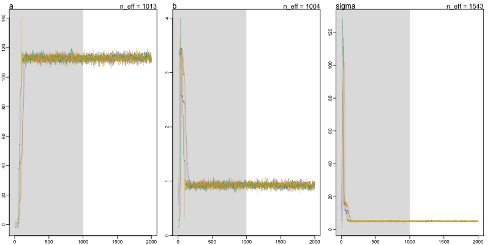

```
> precis(fit)
        mean   sd   5.5%  94.5% n_eff Rhat4
a     112.97 2.00 109.83 116.19  1013  1.01
b       0.92 0.04   0.86   0.99  1004  1.01
sigma   5.08 0.20   4.78   5.40  1543  1.00
```

### Model checking

After fitting the model, we can use the posterior to simulate synthetic data and compare to the data used to fit the model. Discrepancies can suggest paths to improve the model.

### Posterior simulations

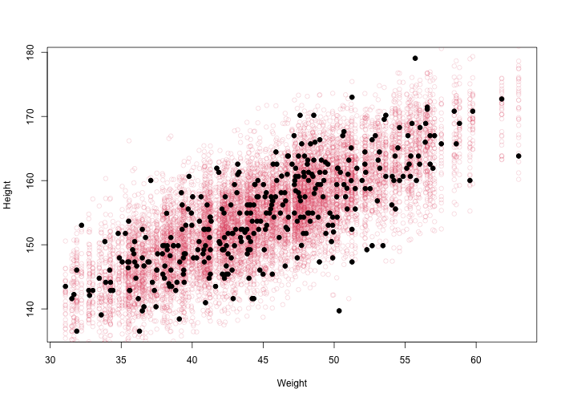

### Posterior correlations

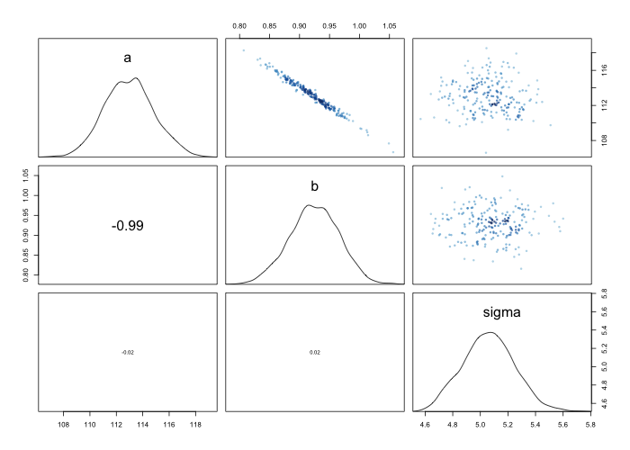

### Reparametrization

```python
ulam(alist(
  y ~ normal(mu, sigma),
  mu <- a + b * x,
  a ~ normal(0, 1),
  b ~ lognormal(0, 1),
  sigma ~ exponential(1)),
  data = list(y = d2$height - mean(d2$height),
              x = (d2$weight - mean(d2$weight))/sd(d2$weight)),
  iter = 1000, chains = 4, cores = 4)
```

### Posterior after centering

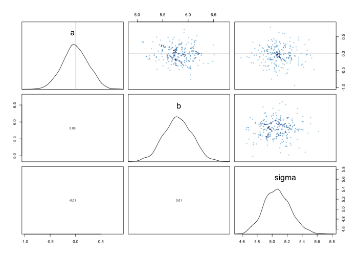

### Collinear predictors

The posterior can be used to interpret weird results.

Returning to the primate milk example:

### Shifting effects

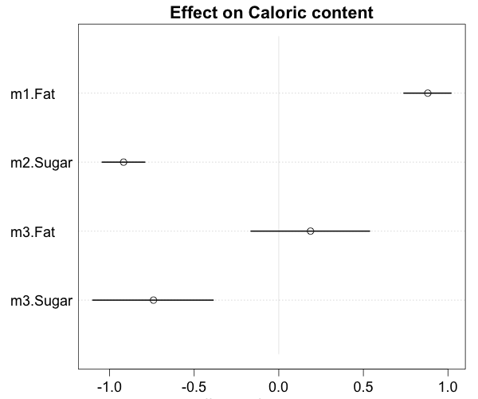

Smaller effects and wider intervals

### Correlated coefficients - m3 model

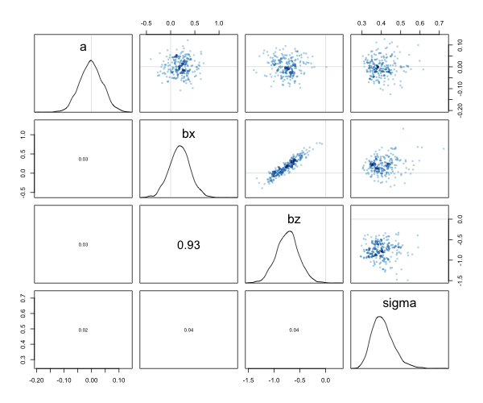

### Correlated predictors

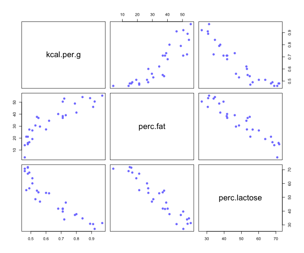